# Krill Respirometry Statistics - Summer 2019 Krill

Author: OA Lab, NWFSC Title: Krill Respirometry Statistics - Summer 2019 Krill Date: February 2021 (R notebook document)

# 1.) Setting Working Directory

```r
#*********************************
## 1.) Setting Working Directory
#*********************************

#set working directory to the correct folder
setwd("/Users/katherinerovinski/GIT/NWFSC.MUK_KRLrespirometrySLOPES_STATs")
```

# 2.) DF Creation

```r
#*********************************
## 2.) Creating the intial Dataframe, dRESP
#*********************************
# 46 Vials Magic Number

# 80% threshold
ksSlopes.80 <- read.csv(file = "2021.02.09_ksSlopes.80.csv", stringsAsFactors = FALSE)

#|- - - - - - - - - - - - - - - - - - - - - - - - - - - - - - - - - - - - - - - - - |

# 70% threshold
ksSlopes.70 <- read.csv(file = "2021.02.09_ksSlopes.70.csv", stringsAsFactors = FALSE)

#|- - - - - - - - - - - - - - - - - - - - - - - - - - - - - - - - - - - - - - - - - |

# 1hr threshold
ksSlopes.1hr  <- read.csv(file = "2021.02.09_ksSlopes.1hr.csv", stringsAsFactors = FALSE)

#|- - - - - - - - - - - - - - - - - - - - - - - - - - - - - - - - - - - - - - - - - |

# all points
dSlopes <- read.csv(file = "2021.02.09_Slopes_allpts.csv", stringsAsFactors = FALSE)

#|- - - - - - - - - - - - - - - - - - - - - - - - - - - - - - - - - - - - - - - - - |
```

# 3.) Summary Statisitics on the Unfiltered Dataframe dSlopes

```r
# factor(dSlopes$TrialID)
#
# dSlopes <- filter(dSlopes, Treatment != "AMB")
# dSlopes<- droplevels(filter(dSlopes, Treatment != "AMB"))
#ksSlopes.1hr<- droplevels(filter(ksSlopes1hr, Treatment != "n/a"))

ksSlopes1hr.summary <- ksSlopes.1hr %>% group_by(Treatment) %>%
  dplyr::summarize(sd = sd(CorrSlope, na.rm = TRUE),
            mean = mean(CorrSlope, na.rm = TRUE),
            median = median(CorrSlope, na.rm = TRUE),
            IQR = IQR(CorrSlope, na.rm = TRUE),
            n = n()) %>%
  mutate(se = sd/sqrt(n)) %>%
  mutate(ci = se*1.96)
ksSlopes1hr.summary
```

| Treatment | sd | mean | median | IQR | n | se | ci |
| --- | --- | --- | --- | --- | --- | --- | --- |
| CHG | 0.005583358 | -0.001776208 | -0.002036407 | 0.004907458 | 16 | 0.001395839 | 0.002735845 |
| CUR | 0.011298257 | 0.002379594 | 0.001020978 | 0.005144002 | 19 | 0.002591998 | 0.005080316 |
| TMP | 0.004838440 | -0.002500531 | -0.003650568 | 0.005695567 | 16 | 0.001209610 | 0.002370835 |

```r
SlopeTable.1hr <- kable(ksSlopes1hr.summary, digits = 4)

write.csv(ksSlopes1hr.summary, "2021.02.09_ksSlopes.1hr_summary.csv")

#|- - - - - - - - - - - - - - - - - - - - - - - - - - - - - - - - - - - - - - - - - |

ksSlopes80.summary <- ksSlopes.80 %>% group_by(Treatment) %>%
  dplyr::summarize(sd = sd(CorrSlope, na.rm = TRUE),
            mean = mean(CorrSlope, na.rm = TRUE),
            median = median(CorrSlope, na.rm = TRUE),
            IQR = IQR(CorrSlope, na.rm = TRUE),
            n = n()) %>%
  mutate(se = sd/sqrt(n)) %>%
  mutate(ci = se*1.96)
ksSlopes80.summary
```

| Treatment | sd | mean | median | IQR | n | se | ci |
| --- | --- | --- | --- | --- | --- | --- | --- |
| CHG | 0.004065527 | 0.0005785529 | 0.0014299211 | 0.002052282 | 16 | 0.0010163817 | 0.001992108 |
| CUR | 0.003283892 | -0.0010072002 | -0.0006882532 | 0.003677814 | 19 | 0.0007533765 | 0.001476618 |
| TMP | 0.003494196 | 0.0010753163 | 0.0006012823 | 0.005156133 | 16 | 0.0008735490 | 0.001712156 |

```r
SlopeTable.80 <- kable(ksSlopes80.summary, digits = 4)

write.csv(ksSlopes80.summary, "2021.02.09_ksSlopes.80_summary.csv")

#|- - - - - - - - - - - - - - - - - - - - - - - - - - - - - - - - - - - - - - - - - |

ksSlopes70.summary <- ksSlopes.70 %>% group_by(Treatment) %>%
  dplyr::summarize(sd = sd(CorrSlope, na.rm = TRUE),
            mean = mean(CorrSlope, na.rm = TRUE),
            median = median(CorrSlope, na.rm = TRUE),
            IQR = IQR(CorrSlope, na.rm = TRUE),
            n = n()) %>%
  mutate(se = sd/sqrt(n)) %>%
  mutate(ci = se*1.96)
ksSlopes70.summary
```

| Treatment | sd | mean | median | IQR | n | se | ci |
| --- | --- | --- | --- | --- | --- | --- | --- |
| CHG | 0.003173232 | -0.0004976462 | -4.158713e-05 | 0.002900971 | 16 | 0.0007933080 | 0.001554884 |
| CUR | 0.002298790 | -0.0003071082 | -2.570656e-05 | 0.002418887 | 19 | 0.0005273785 | 0.001033662 |
| TMP | 0.002813950 | 0.0002339053 | 4.077097e-04 | 0.003848429 | 16 | 0.0007034875 | 0.001378835 |

```r
SlopeTable.70 <- kable(ksSlopes70.summary, digits = 4)

write.csv(ksSlopes70.summary, "2021.02.09_ksSlopes.70_summary.csv")

#|- - - - - - - - - - - - - - - - - - - - - - - - - - - - - - - - - - - - - - - - - |

dSlopes.summary <- dSlopes %>% group_by(Treatment) %>%
  dplyr::summarize(sd = sd(CorrSlope, na.rm = TRUE),
            mean = mean(CorrSlope, na.rm = TRUE),
            median = median(CorrSlope, na.rm = TRUE),
            IQR = IQR(CorrSlope, na.rm = TRUE),
            n = n()) %>%
  mutate(se = sd/sqrt(n)) %>%
  mutate(ci = se*1.96)
dSlopes.summary
```

| Treatment | sd | mean | median | IQR | n | se | ci |
| --- | --- | --- | --- | --- | --- | --- | --- |
| CHG | 0.004265618 | -0.008106896 | -0.007795664 | 0.007238001 | 16 | 0.001066405 | 0.002090153 |
| CUR | 0.006674893 | -0.010331173 | -0.009898894 | 0.009208639 | 19 | 0.001531325 | 0.003001398 |
| TMP | 0.006783077 | -0.009752567 | -0.008601520 | 0.009479005 | 16 | 0.001695769 | 0.003323708 |

```r
SlopeTable.allpts <- kable(dSlopes.summary, digits = 4)

write.csv(dSlopes.summary, "2021.02.09_dSlopes_summary.csv")

#|- - - - - - - - - - - - - - - - - - - - - - - - - - - - - - - - - - - - - - - - - |
```

### 3.a Slope Tables 1hr

```r
SlopeTable.1hr <- kable(ksSlopes1hr.summary, digits = 4)
SlopeTable.1hr
```

| Treatment | sd | mean | median | IQR | n | se | ci |
| --- | --- | --- | --- | --- | --- | --- | --- |
| CHG | 0.0056 | -0.0018 | -0.0020 | 0.0049 | 16 | 0.0014 | 0.0027 |
| CUR | 0.0113 | 0.0024 | 0.0010 | 0.0051 | 19 | 0.0026 | 0.0051 |
| TMP | 0.0048 | -0.0025 | -0.0037 | 0.0057 | 16 | 0.0012 | 0.0024 |

### 3.b Slope Tables 80%

```r
SlopeTable.80 <- kable(ksSlopes80.summary, digits = 4)
SlopeTable.80
```

| Treatment | sd | mean | median | IQR | n | se | ci |
| --- | --- | --- | --- | --- | --- | --- | --- |
| CHG | 0.0041 | 0.0006 | 0.0014 | 0.0021 | 16 | 1e-03 | 0.0020 |
| CUR | 0.0033 | -0.0010 | -0.0007 | 0.0037 | 19 | 8e-04 | 0.0015 |
| TMP | 0.0035 | 0.0011 | 0.0006 | 0.0052 | 16 | 9e-04 | 0.0017 |

### 3.c Slope Tables 70%

```r
SlopeTable.70 <- kable(ksSlopes70.summary, digits = 4)
SlopeTable.70
```

| Treatment | sd | mean | median | IQR | n | se | ci |
| --- | --- | --- | --- | --- | --- | --- | --- |
| CHG | 0.0032 | -5e-04 | 0e+00 | 0.0029 | 16 | 8e-04 | 0.0016 |
| CUR | 0.0023 | -3e-04 | 0e+00 | 0.0024 | 19 | 5e-04 | 0.0010 |
| TMP | 0.0028 | 2e-04 | 4e-04 | 0.0038 | 16 | 7e-04 | 0.0014 |

### 3.d Slope Tables all points

```r
dSlopeTable <- kable(dSlopes.summary, digits = 4)
dSlopeTable
```

| Treatment | sd | mean | median | IQR | n | se | ci |
| --- | --- | --- | --- | --- | --- | --- | --- |
| CHG | 0.0043 | -0.0081 | -0.0078 | 0.0072 | 16 | 0.0011 | 0.0021 |
| CUR | 0.0067 | -0.0103 | -0.0099 | 0.0092 | 19 | 0.0015 | 0.0030 |
| TMP | 0.0068 | -0.0098 | -0.0086 | 0.0095 | 16 | 0.0017 | 0.0033 |

# 4.) Summary Plots

## 4.a 80% Threshold Corrected Slopes

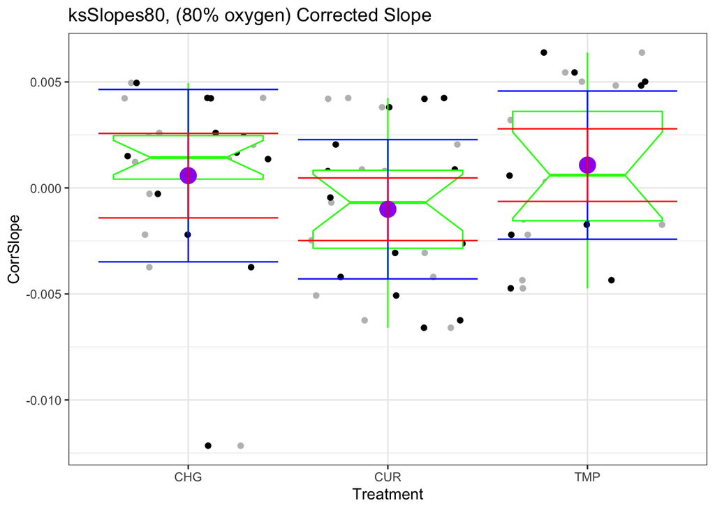

```r
plot80 <- ggplot(ksSlopes.80, aes(Treatment, CorrSlope)) +
            geom_jitter(color = "grey") +
            geom_jitter(data = ksSlopes.80, aes(Treatment, CorrSlope)) +
            # geom_jitter(data = krillslopes80.filtered, aes(Treatment, slope)) +
            # geom_jitter(data = krillslopes70.filtered, aes(Treatment, slope)) +
            # geom_jitter(data = T1to4krillslopes.filtered, aes(Treatment, slope)) +
            # geom_jitter(aes(colour = Treatment)) +
            geom_boxplot(notch = TRUE, outlier.shape = NA, colour = "green") +
            geom_point(data = ksSlopes80.summary, aes(x=Treatment, y=mean), size=5, color = "purple") +
            geom_errorbar(data = ksSlopes80.summary,
                          aes(x=Treatment, y=mean, ymin = mean-sd, ymax = mean+sd),
                          color = "blue") +
            geom_errorbar(data = ksSlopes80.summary,
                          aes(x=Treatment, y=mean, ymin = mean-ci, ymax = mean+ci),
                          colour = "red") +
            # facet_wrap(~TrialID) +
            ggtitle("ksSlopes80, (80% oxygen) Corrected Slope") +
            theme_bw()


plot80
```

The purple dots represent the mean- all trials included Confidence Intervals set to 95 Green boxplots show from the 25th percentil to the 75th percentile error bars +/- SD shown in blue error bars(CI) +/- our confidence intervals- shown in red

## 4.b Plots 70% Slope for Corrected Slopes

```
## notch went outside hinges. Try setting notch=FALSE.
## notch went outside hinges. Try setting notch=FALSE.
```

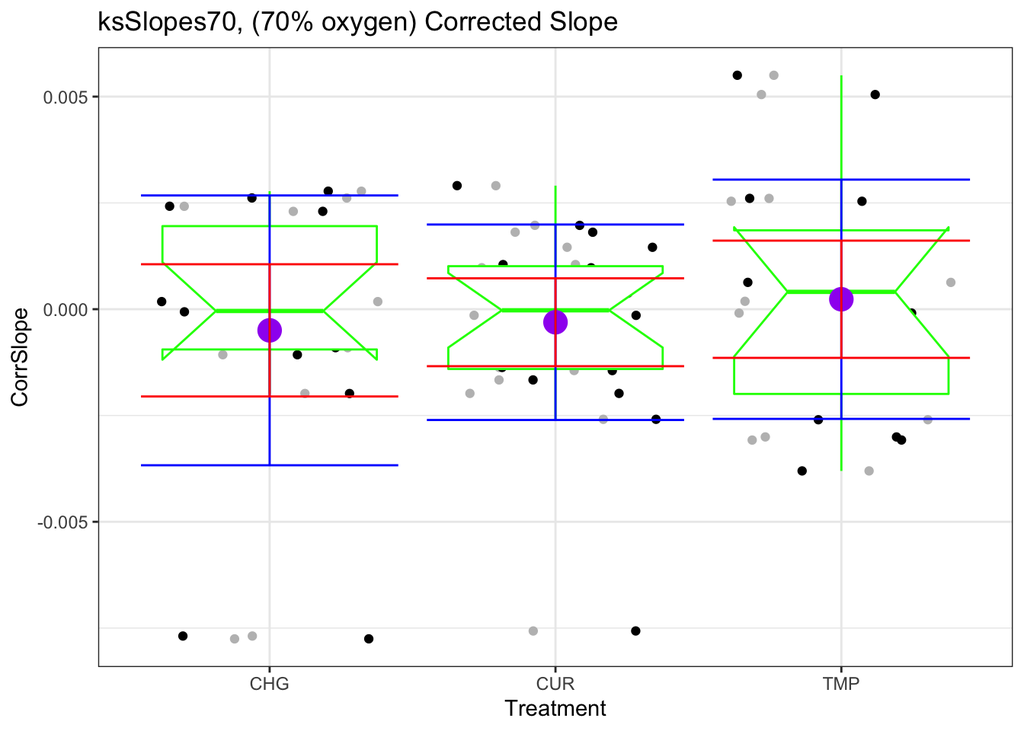

```r
plot70 <- ggplot(ksSlopes.70, aes(Treatment, CorrSlope)) +
            geom_jitter(color = "grey") +
            geom_jitter(data = ksSlopes.70, aes(Treatment, CorrSlope)) +
            # geom_jitter(data = krillslopes80.filtered, aes(Treatment, slope)) +
            # geom_jitter(data = krillslopes70.filtered, aes(Treatment, slope)) +
            # geom_jitter(data = T1to4krillslopes.filtered, aes(Treatment, slope)) +
            # geom_jitter(aes(colour = Treatment)) +
            geom_boxplot(notch = TRUE, outlier.shape = NA, colour = "green") +
            geom_point(data = ksSlopes70.summary, aes(x=Treatment, y=mean), size=5, color = "purple") +
            geom_errorbar(data = ksSlopes70.summary,
                          aes(x=Treatment, y=mean, ymin = mean-sd, ymax = mean+sd),
                          color = "blue") +
            geom_errorbar(data = ksSlopes70.summary,
                          aes(x=Treatment, y=mean, ymin = mean-ci, ymax = mean+ci),
                          colour = "red") +
            # facet_wrap(~TrialID) +
            ggtitle("ksSlopes70, (70% oxygen) Corrected Slope") +
            theme_bw()

plot70
```

The purple dots represent the mean- all trials included Confidence Intervals set to 95 Green boxplots show from the 25th percentil to the 75th percentile error bars +/- SD shown in blue error bars(CI) +/- our confidence intervals- shown in red

## 4.c Plots threshold (1hr) Slope for Corrected Slopes

```
## notch went outside hinges. Try setting notch=FALSE.
## notch went outside hinges. Try setting notch=FALSE.
```

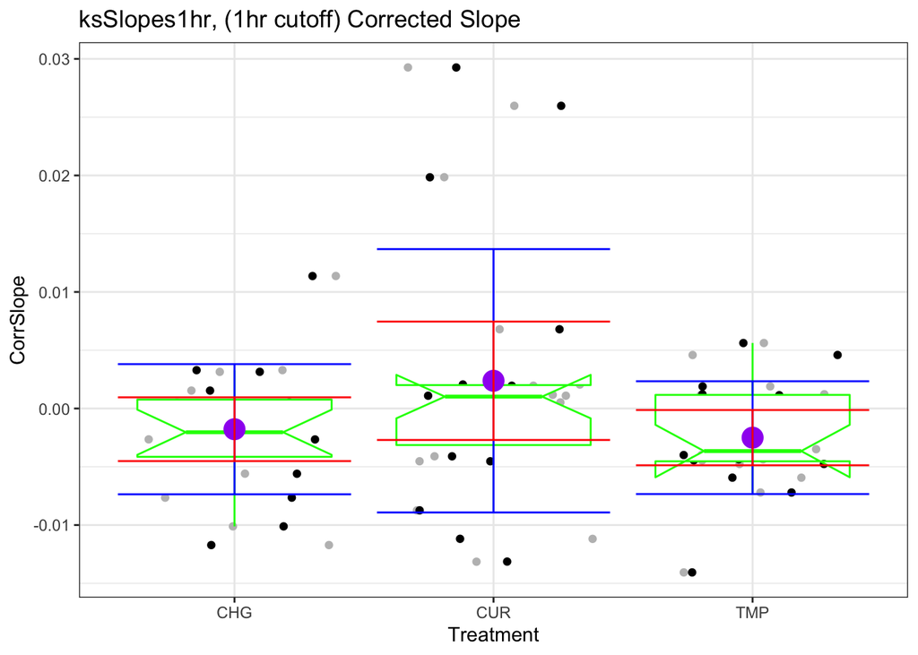

```r
Onehrplot <- ggplot(ksSlopes.1hr, aes(Treatment, CorrSlope)) +
            geom_jitter(color = "grey") +
            geom_jitter(data = ksSlopes.1hr, aes(Treatment, CorrSlope)) +
            # geom_jitter(data = krillslopes80.filtered, aes(Treatment, slope)) +
            # geom_jitter(data = krillslopes70.filtered, aes(Treatment, slope)) +
            # geom_jitter(data = T1to4krillslopes.filtered, aes(Treatment, slope)) +
            # geom_jitter(aes(colour = Treatment)) +
            geom_boxplot(notch = TRUE, outlier.shape = NA, colour = "green") +
            geom_point(data = ksSlopes1hr.summary, aes(x=Treatment, y=mean), size=5, color = "purple") +
            geom_errorbar(data = ksSlopes1hr.summary,
                          aes(x=Treatment, y=mean, ymin = mean-sd, ymax = mean+sd),
                          color = "blue") +
            geom_errorbar(data = ksSlopes1hr.summary,
                          aes(x=Treatment, y=mean, ymin = mean-ci, ymax = mean+ci),
                          colour = "red") +
            # facet_wrap(~TrialID) +
            ggtitle("ksSlopes1hr, (1hr cutoff) Corrected Slope") +
            theme_bw()

Onehrplot
```

The purple dots represent the mean- all trials included Confidence Intervals set to 95 Green boxplots show from the 25th percentil to the 75th percentile error bars +/- SD shown in blue error bars(CI) +/- our confidence intervals- shown in red

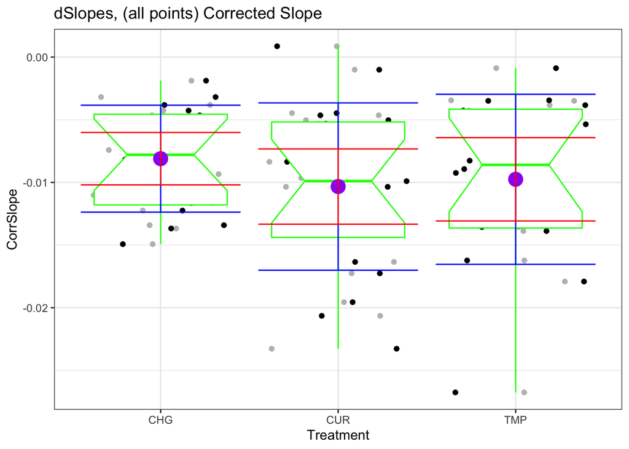

```r
dSlopesPlot <- ggplot(dSlopes, aes(Treatment, CorrSlope)) +
            geom_jitter(color = "grey") +
            geom_jitter(data = dSlopes, aes(Treatment, CorrSlope)) +
            # geom_jitter(data = krillslopes80.filtered, aes(Treatment, slope)) +
            # geom_jitter(data = krillslopes70.filtered, aes(Treatment, slope)) +
            # geom_jitter(data = T1to4krillslopes.filtered, aes(Treatment, slope)) +
            # geom_jitter(aes(colour = Treatment)) +
            geom_boxplot(notch = TRUE, outlier.shape = NA, colour = "green") +
            geom_point(data = dSlopes.summary, aes(x=Treatment, y=mean), size=5, color = "purple") +
            geom_errorbar(data = dSlopes.summary,
                          aes(x=Treatment, y=mean, ymin = mean-sd, ymax = mean+sd),
                          color = "blue") +
            geom_errorbar(data = dSlopes.summary,
                          aes(x=Treatment, y=mean, ymin = mean-ci, ymax = mean+ci),
                          colour = "red") +
            # facet_wrap(~TrialID) +
            ggtitle("dSlopes, (all points) Corrected Slope") +
            theme_bw()
dSlopesPlot
```

# 5.) Descriptive Statisitics

```r
library(tidyr)
#Remove NAs
#krill <- na.omit(krill)
#Calculate mean and standard deviation for each treatment per each dataset
# blanks are to be removed from treatments

# dSlopes<- droplevels(filter(dSlopes, Treatment != "n/a"))
# ksSlopes80<- droplevels(filter(ksSlopes80, Treatment != "n/a"))
# ksSlopes70<- droplevels(filter(ksSlopes70, Treatment != "n/a"))
# ksSlopes1hr<- droplevels(filter(ksSlopes1hr, Treatment != "n/a"))


dSlopes_Avg <- tapply(dSlopes$CorrSlope, (dSlopes$Treatment), mean)
dSlopes_Med <- tapply(dSlopes$CorrSlope, (dSlopes$Treatment), median)
dSlopes_Std <- tapply(dSlopes$CorrSlope, (dSlopes$Treatment), sd)

ksSlopes.80_Avg <- tapply(ksSlopes.80$CorrSlope, (ksSlopes.80$Treatment), mean)
ksSlopes.80_Med <- tapply(ksSlopes.80$CorrSlope, (ksSlopes.80$Treatment), median)
ksSlopes.80_Std <- tapply(ksSlopes.80$CorrSlope, (ksSlopes.80$Treatment), sd)

ksSlopes.70_Avg <- tapply(ksSlopes.70$CorrSlope, (ksSlopes.70$Treatment), mean)
ksSlopes.70_Med <- tapply(ksSlopes.70$CorrSlope, (ksSlopes.70$Treatment), median)
ksSlopes.70_Std <- tapply(ksSlopes.70$CorrSlope, (ksSlopes.70$Treatment), sd)

ksSlopes.1hr_Avg <- tapply(ksSlopes.1hr$CorrSlope, (ksSlopes.1hr$Treatment), mean)
ksSlopes.1hr_Med <- tapply(ksSlopes.1hr$CorrSlope, (ksSlopes.1hr$Treatment), median)
ksSlopes.1hr_Std <- tapply(ksSlopes.1hr$CorrSlope, (ksSlopes.1hr$Treatment), sd)


#Put it all together
Slope_Stats <- cbind(dSlopes_Avg, dSlopes_Med, dSlopes_Std,
                     ksSlopes.80_Avg, ksSlopes.80_Med, ksSlopes.80_Std,
                     ksSlopes.70_Avg, ksSlopes.70_Med, ksSlopes.70_Std,
                     ksSlopes.1hr_Avg, ksSlopes.1hr_Med, ksSlopes.1hr_Std)

colnames(Slope_Stats) [1:12] <-c("Avg All Points Corrected Slopes", "Med All Points Corrected Slopes", "All Points Corrected Slopes SD", "Avg 80% DO Corrected Slopes", "Med 80% DO Corrected Slopes", "80% DO Corrected Slopes SD", "Avg 70% DO Corrected Slopes", "Med 70% DO Corrected Slopes", "70% DO Corrected Slopes SD", "Avg 1hr Corrected Slopes", "Med 1hr Corrected Slopes", "1hr Corrected Slopes SD")


write.csv(Slope_Stats, "2021.02.09_Slope_Stats.csv")

kable(Slope_Stats)
```

|  | Avg All Points Corrected Slopes | Med All Points Corrected Slopes | All Points Corrected Slopes SD | Avg 80% DO Corrected Slopes | Med 80% DO Corrected Slopes | 80% DO Corrected Slopes SD | Avg 70% DO Corrected Slopes | Med 70% DO Corrected Slopes | 70% DO Corrected Slopes SD | Avg 1hr Corrected Slopes | Med 1hr Corrected Slopes | 1hr Corrected Slopes SD |
| --- | --- | --- | --- | --- | --- | --- | --- | --- | --- | --- | --- | --- |
| CHG | -0.0081069 | -0.0077957 | 0.0042656 | 0.0005786 | 0.0014299 | 0.0040655 | -0.0004976 | -0.0000416 | 0.0031732 | -0.0017762 | -0.0020364 | 0.0055834 |
| CUR | -0.0103312 | -0.0098989 | 0.0066749 | -0.0010072 | -0.0006883 | 0.0032839 | -0.0003071 | -0.0000257 | 0.0022988 | 0.0023796 | 0.0010210 | 0.0112983 |
| TMP | -0.0097526 | -0.0086015 | 0.0067831 | 0.0010753 | 0.0006013 | 0.0034942 | 0.0002339 | 0.0004077 | 0.0028139 | -0.0025005 | -0.0036506 | 0.0048384 |

# 6.) Fitting my Linear Mixed-Effects Models to my Dataframes

```r
#Using a mixed model to find significant differences bertween MOATs
#library(nlme)
library(lme4)
library(lmerTest)

# Corrected Slopes , Treatment taking into account MOATS


# ksSlopes.80<- droplevels(filter(ksSlopes.80, Treatment != "n/a"))
# ksSlopes.70<- droplevels(filter(ksSlopes.70, Treatment != "n/a"))
# ksSlopes.1hr<- droplevels(filter(ksSlopes.1hr, Treatment != "n/a"))
# dSlopes<- droplevels(filter(dSlopes, Treatment != "n/a"))


ksSlopes.1hr_howmanyanimalsin_CHG <- subset(ksSlopes.1hr, Treatment == "CHG")
ks1hrCHGno <- unique(ksSlopes.1hr_howmanyanimalsin_CHG$KrillID)
# 16 animals in All Change across 4 trials

ksSlopes.1hr_howmanyanimalsin_CUR <- subset(ksSlopes.1hr, Treatment == "CUR")
ks1hrCURno <- unique(ksSlopes.1hr_howmanyanimalsin_CUR$KrillID)
# 19 animals from Current Treatment across 4 trials

ksSlopes.1hr_howmanyanimalsin_TMP <- subset(ksSlopes.1hr, Treatment == "TMP")
ks1hrTMPno <- unique(ksSlopes.1hr_howmanyanimalsin_TMP$KrillID)
# 16 animals in high Temperature Treatment across 4 trials


16+19+16
```

```
## [1] 51
```

```r
# [1] 51
```

#### 6.a 1hr Dataframe - LMER

```r
lmer.ksSlopes.1hr <- lmer(CorrSlope ~ Treatment + (1|MOATS), data = ksSlopes.1hr)
summary(lmer.ksSlopes.1hr)
```

```
## Linear mixed model fit by REML. t-tests use Satterthwaite's method [
## lmerModLmerTest]
## Formula: CorrSlope ~ Treatment + (1 | MOATS)
##    Data: ksSlopes.1hr
##
## REML criterion at convergence: -329.1
##
## Scaled residuals:
##      Min       1Q   Median       3Q      Max
## -1.68638 -0.47569  0.00437  0.51632  2.75955
##
## Random effects:
##  Groups   Name        Variance  Std.Dev.
##  MOATS    (Intercept) 3.441e-05 0.005866
##  Residual             4.178e-05 0.006464
## Number of obs: 51, groups:  MOATS, 9
##
## Fixed effects:
##               Estimate Std. Error        df t value Pr(>|t|)
## (Intercept)  -0.001302   0.003369  8.777260  -0.386    0.708
## TreatmentCUR  0.004016   0.004212 14.743842   0.953    0.356
## TreatmentTMP -0.001199   0.005583  6.333602  -0.215    0.837
##
## Correlation of Fixed Effects:
##             (Intr) TrtCUR
## TreatmntCUR -0.670
## TreatmntTMP -0.604  0.405
```

```r
# All Change Against Current
# All Change Against High Temperature
```

“1hr Dataset” - No Treatment Effect Found

#### 6.b 1hr Dataframe - LMER releved Current 1st

```r
levels(ksSlopes.1hr$Treatment)
```

```r
# lmer.ksSlopes.1hr
ksSlopes.1hr$Treatment <- fct_relevel(ksSlopes.1hr$Treatment, "CUR")
lmer.ksSlopes.1hr <- lmer(CorrSlope ~ Treatment + (1|MOATS), data = ksSlopes.1hr)
summary(lmer.ksSlopes.1hr)
```

```
## Linear mixed model fit by REML. t-tests use Satterthwaite's method [
## lmerModLmerTest]
## Formula: CorrSlope ~ Treatment + (1 | MOATS)
##    Data: ksSlopes.1hr
##
## REML criterion at convergence: -329.1
##
## Scaled residuals:
##      Min       1Q   Median       3Q      Max
## -1.68638 -0.47569  0.00437  0.51632  2.75955
##
## Random effects:
##  Groups   Name        Variance  Std.Dev.
##  MOATS    (Intercept) 3.441e-05 0.005866
##  Residual             4.178e-05 0.006464
## Number of obs: 51, groups:  MOATS, 9
##
## Fixed effects:
##               Estimate Std. Error        df t value Pr(>|t|)
## (Intercept)   0.002713   0.003173  8.789085   0.855    0.415
## TreatmentCHG -0.004016   0.004212 14.743842  -0.953    0.356
## TreatmentTMP -0.005214   0.005467  6.253781  -0.954    0.376
##
## Correlation of Fixed Effects:
##             (Intr) TrtCHG
## TreatmntCHG -0.616
## TreatmntTMP -0.580  0.357
```

The Current Conditions to Hight Temperature comparison did not display a treatment effect.

Possible reasons for such small amount of variance include only 51 animals in trial. 16 animals from the “All Change” treatment were in included across four trials. 19 animals from the “Current” treatment were in included across four trials. 16 animals from the “High Temperarure” treatment were in included across four trials. (totals 51 animals)

so signal over the noise- why?

1hr may not have allowed enough observations to show a disernable difference across treatments. However, Krill could just be proving to be a robust organism, able to withstand a cross stress environment. It’s more likely that sample size was small.

#### 6.c 80% Threshold Dataframe - LMER

```r
lmer.ksSlopes.80 <- lmer(CorrSlope ~ Treatment + (1|MOATS), data = ksSlopes.80)
summary(lmer.ksSlopes.80)
```

```
## Linear mixed model fit by REML. t-tests use Satterthwaite's method [
## lmerModLmerTest]
## Formula: CorrSlope ~ Treatment + (1 | MOATS)
##    Data: ksSlopes.80
##
## REML criterion at convergence: -395.3
##
## Scaled residuals:
##     Min      1Q  Median      3Q     Max
## -3.4943 -0.5586  0.1519  0.5739  1.4604
##
## Random effects:
##  Groups   Name        Variance  Std.Dev.
##  MOATS    (Intercept) 2.347e-07 0.0004845
##  Residual             1.287e-05 0.0035869
## Number of obs: 51, groups:  MOATS, 9
##
## Fixed effects:
##                Estimate Std. Error         df t value Pr(>|t|)
## (Intercept)   0.0005746  0.0009346  7.6538185   0.615    0.557
## TreatmentCUR -0.0016000  0.0012697  7.5087302  -1.260    0.245
## TreatmentTMP  0.0005007  0.0013398  4.4345997   0.374    0.726
##
## Correlation of Fixed Effects:
##             (Intr) TrtCUR
## TreatmntCUR -0.733
## TreatmntTMP -0.698  0.511
```

```r
# All Change Against Current
# All Change Against High Temperature
```

#### 6.d 80% Threshold - LMER releved Current 1st

```r
levels(ksSlopes.80$Treatment)
```

```r
# lmer.ksSlopes.1hr
ksSlopes.80$Treatment <- fct_relevel(ksSlopes.80$Treatment, "CUR")
lmer.ksSlopes.80 <- lmer(CorrSlope ~ Treatment + (1|MOATS), data = ksSlopes.80)
summary(lmer.ksSlopes.80)
```

```
## Linear mixed model fit by REML. t-tests use Satterthwaite's method [
## lmerModLmerTest]
## Formula: CorrSlope ~ Treatment + (1 | MOATS)
##    Data: ksSlopes.80
##
## REML criterion at convergence: -395.3
##
## Scaled residuals:
##     Min      1Q  Median      3Q     Max
## -3.4943 -0.5586  0.1519  0.5739  1.4604
##
## Random effects:
##  Groups   Name        Variance  Std.Dev.
##  MOATS    (Intercept) 2.347e-07 0.0004845
##  Residual             1.287e-05 0.0035869
## Number of obs: 51, groups:  MOATS, 9
##
## Fixed effects:
##                Estimate Std. Error         df t value Pr(>|t|)
## (Intercept)  -0.0010254  0.0008642  5.6876601  -1.187    0.283
## TreatmentCHG  0.0016000  0.0012697  7.5087302   1.260    0.245
## TreatmentTMP  0.0021007  0.0012916  3.8400049   1.626    0.182
##
## Correlation of Fixed Effects:
##             (Intr) TrtCHG
## TreatmntCHG -0.677
## TreatmntTMP -0.669  0.453
```

When comparing Current against “High Temperature” and “All Change” the T values remain small but the TMP to CUR is somewhat larger.

Still, no discernible treatment effect, no discernible MOATS effect.

#### 6.e 70% Threshold Dataframe - LMER

```r
lmer.ksSlopes.70 <- lmer(CorrSlope ~ Treatment + (1|MOATS), data = ksSlopes.70)
summary(lmer.ksSlopes.70)
```

```
## Linear mixed model fit by REML. t-tests use Satterthwaite's method [
## lmerModLmerTest]
## Formula: CorrSlope ~ Treatment + (1 | MOATS)
##    Data: ksSlopes.70
##
## REML criterion at convergence: -431.4
##
## Scaled residuals:
##     Min      1Q  Median      3Q     Max
## -3.1536 -0.5207  0.1268  0.5546  1.5776
##
## Random effects:
##  Groups   Name        Variance  Std.Dev.
##  MOATS    (Intercept) 3.331e-06 0.001825
##  Residual             5.069e-06 0.002251
## Number of obs: 51, groups:  MOATS, 9
##
## Fixed effects:
##                Estimate Std. Error         df t value Pr(>|t|)
## (Intercept)  -3.876e-04  1.089e-03  9.300e+00  -0.356    0.730
## TreatmentCUR  1.416e-05  1.384e-03  1.437e+01   0.010    0.992
## TreatmentTMP  6.215e-04  1.780e-03  6.780e+00   0.349    0.738
##
## Correlation of Fixed Effects:
##             (Intr) TrtCUR
## TreatmntCUR -0.680
## TreatmntTMP -0.612  0.416
```

```r
# All Change Against Current
# All Change Against High Temperature
```

#### 6.f 70% Threshold - LMER releved Current 1st

```r
levels(ksSlopes.70$Treatment)
```

```r
# lmer.ksSlopes.1hr
ksSlopes.70$Treatment <- fct_relevel(ksSlopes.70$Treatment, "CUR")
lmer.ksSlopes.70 <- lmer(CorrSlope ~ Treatment + (1|MOATS), data = ksSlopes.70)
summary(lmer.ksSlopes.70)
```

```
## Linear mixed model fit by REML. t-tests use Satterthwaite's method [
## lmerModLmerTest]
## Formula: CorrSlope ~ Treatment + (1 | MOATS)
##    Data: ksSlopes.70
##
## REML criterion at convergence: -431.4
##
## Scaled residuals:
##     Min      1Q  Median      3Q     Max
## -3.1536 -0.5207  0.1268  0.5546  1.5776
##
## Random effects:
##  Groups   Name        Variance  Std.Dev.
##  MOATS    (Intercept) 3.331e-06 0.001825
##  Residual             5.069e-06 0.002251
## Number of obs: 51, groups:  MOATS, 9
##
## Fixed effects:
##                Estimate Std. Error         df t value Pr(>|t|)
## (Intercept)  -3.734e-04  1.025e-03  9.401e+00  -0.364    0.724
## TreatmentCHG -1.416e-05  1.384e-03  1.437e+01  -0.010    0.992
## TreatmentTMP  6.073e-04  1.742e-03  6.715e+00   0.349    0.738
##
## Correlation of Fixed Effects:
##             (Intr) TrtCHG
## TreatmntCHG -0.628
## TreatmntTMP -0.589  0.370
```

Below shows the comparison is slopes values when all data points were considered.

#### 6.g All Points “dSlopes” Dataframe - LMER

```r
lmer.dSlopes<- lmer(CorrSlope ~ Treatment + (1|MOATS), data = dSlopes)
```

```
## boundary (singular) fit: see ?isSingular
```

```r
summary(lmer.dSlopes)
```

```
## Linear mixed model fit by REML. t-tests use Satterthwaite's method [
## lmerModLmerTest]
## Formula: CorrSlope ~ Treatment + (1 | MOATS)
##    Data: dSlopes
##
## REML criterion at convergence: -345.4
##
## Scaled residuals:
##     Min      1Q  Median      3Q     Max
## -2.8039 -0.6542  0.1125  0.7677  1.8463
##
## Random effects:
##  Groups   Name        Variance  Std.Dev.
##  MOATS    (Intercept) 0.000e+00 0.000000
##  Residual             3.677e-05 0.006064
## Number of obs: 51, groups:  MOATS, 9
##
## Fixed effects:
##               Estimate Std. Error        df t value Pr(>|t|)
## (Intercept)  -0.008107   0.001516 48.000000  -5.348 2.44e-06 ***
## TreatmentCUR -0.002224   0.002058 48.000000  -1.081    0.285
## TreatmentTMP -0.001646   0.002144 48.000000  -0.768    0.446
## ---
## Signif. codes:  0 '***' 0.001 '**' 0.01 '*' 0.05 '.' 0.1 ' ' 1
##
## Correlation of Fixed Effects:
##             (Intr) TrtCUR
## TreatmntCUR -0.737
## TreatmntTMP -0.707  0.521
## optimizer (nloptwrap) convergence code: 0 (OK)
## boundary (singular) fit: see ?isSingular
```

```r
# All Change Against Current
# All Change Against High Temperature
```

The variance around a MOATs effect remains so significantly small. No MOATs effect No treatment effect observed. Model re-organized/re-leveled below to compare “Current” against “High Temperature” directly

#### 6.f) All Points - LMER releved Current 1st

```r
levels(dSlopes$Treatment)
```

```r
dSlopes$Treatment <- fct_relevel(dSlopes$Treatment, "CUR")
lmer.dSlopes <- lmer(CorrSlope ~ Treatment + (1|MOATS), data = dSlopes)
```

```
## boundary (singular) fit: see ?isSingular
```

```r
summary(lmer.dSlopes)
```

```
## Linear mixed model fit by REML. t-tests use Satterthwaite's method [
## lmerModLmerTest]
## Formula: CorrSlope ~ Treatment + (1 | MOATS)
##    Data: dSlopes
##
## REML criterion at convergence: -345.4
##
## Scaled residuals:
##     Min      1Q  Median      3Q     Max
## -2.8039 -0.6542  0.1125  0.7677  1.8463
##
## Random effects:
##  Groups   Name        Variance  Std.Dev.
##  MOATS    (Intercept) 0.000e+00 0.000000
##  Residual             3.677e-05 0.006064
## Number of obs: 51, groups:  MOATS, 9
##
## Fixed effects:
##                Estimate Std. Error         df t value Pr(>|t|)
## (Intercept)  -0.0103312  0.0013912 48.0000000  -7.426 1.64e-09 ***
## TreatmentCHG  0.0022243  0.0020576 48.0000000   1.081    0.285
## TreatmentTMP  0.0005786  0.0020576 48.0000000   0.281    0.780
## ---
## Signif. codes:  0 '***' 0.001 '**' 0.01 '*' 0.05 '.' 0.1 ' ' 1
##
## Correlation of Fixed Effects:
##             (Intr) TrtCHG
## TreatmntCHG -0.676
## TreatmntTMP -0.676  0.457
## optimizer (nloptwrap) convergence code: 0 (OK)
## boundary (singular) fit: see ?isSingular
```

```r
#
# # Just a chunk of the models held back case I need them.
#
# lmer.ksSlopes.80 <- lmer(CorrSlope ~ Treatment + (1|MOATS), data = ksSlopes.80)
# summary(lmer.ksSlopes.80)
#
# lmer.ksSlopes.70 <- lmer(CorrSlope ~ Treatment + (1|MOATS), data = ksSlopes.70)
# summary(lmer.ksSlopes.70)
#
# lmer.dSlopes <- lmer(CorrSlope ~ Treatment + (1|MOATS), data = dSlopes)
# summary(lmer.dSlopes)
#
#
#
# # what about different rounds on different days?
```

```
## notch went outside hinges. Try setting notch=FALSE.
## notch went outside hinges. Try setting notch=FALSE.
```

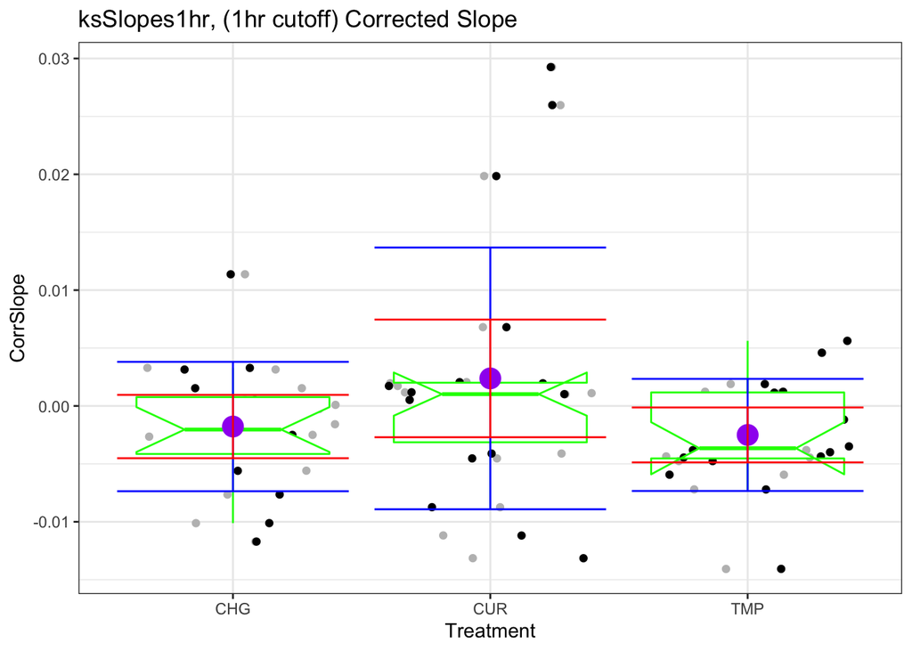

```r
Onehrplot
```

```
## notch went outside hinges. Try setting notch=FALSE.
## notch went outside hinges. Try setting notch=FALSE.
```

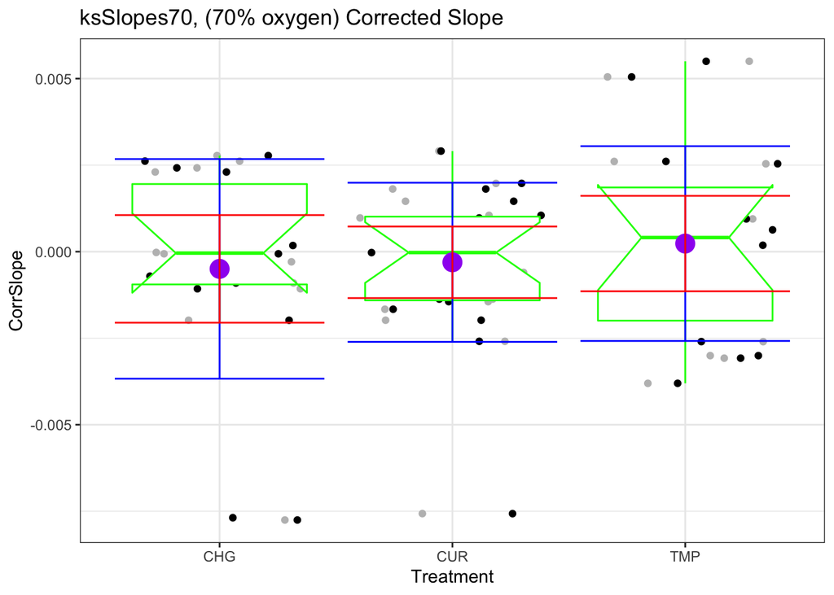

```r
plot70
```

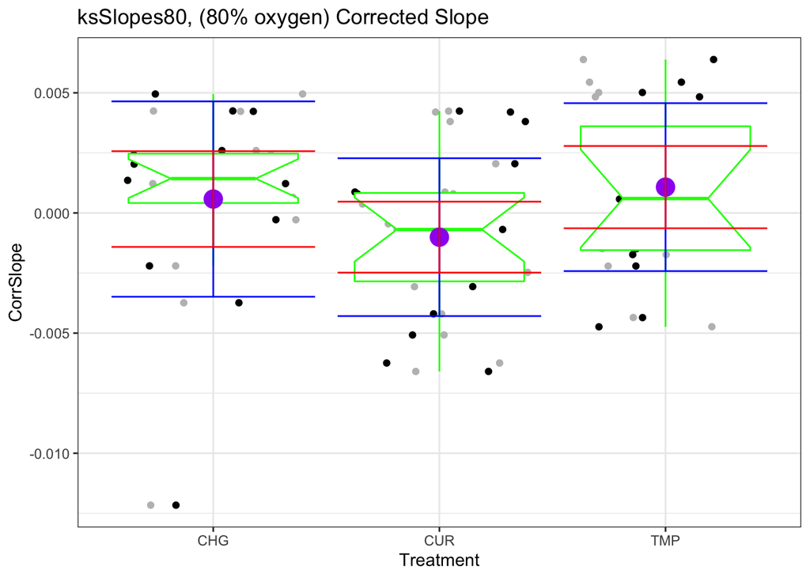

```r
plot80
```

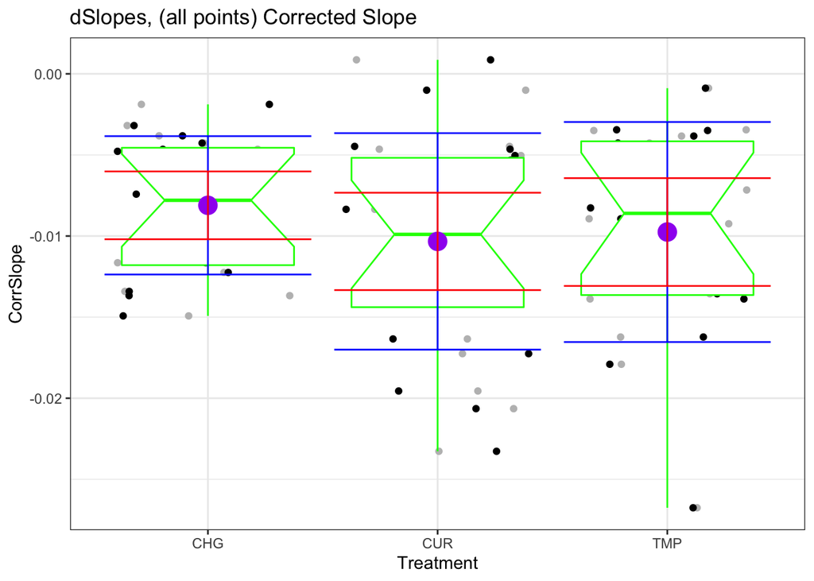

```r
dSlopesPlot
```

*Slope Statistics*

```r
kable(Slope_Stats)
```

|  | Avg All Points Corrected Slopes | Med All Points Corrected Slopes | All Points Corrected Slopes SD | Avg 80% DO Corrected Slopes | Med 80% DO Corrected Slopes | 80% DO Corrected Slopes SD | Avg 70% DO Corrected Slopes | Med 70% DO Corrected Slopes | 70% DO Corrected Slopes SD | Avg 1hr Corrected Slopes | Med 1hr Corrected Slopes | 1hr Corrected Slopes SD |
| --- | --- | --- | --- | --- | --- | --- | --- | --- | --- | --- | --- | --- |
| CHG | -0.0081069 | -0.0077957 | 0.0042656 | 0.0005786 | 0.0014299 | 0.0040655 | -0.0004976 | -0.0000416 | 0.0031732 | -0.0017762 | -0.0020364 | 0.0055834 |
| CUR | -0.0103312 | -0.0098989 | 0.0066749 | -0.0010072 | -0.0006883 | 0.0032839 | -0.0003071 | -0.0000257 | 0.0022988 | 0.0023796 | 0.0010210 | 0.0112983 |
| TMP | -0.0097526 | -0.0086015 | 0.0067831 | 0.0010753 | 0.0006013 | 0.0034942 | 0.0002339 | 0.0004077 | 0.0028139 | -0.0025005 | -0.0036506 | 0.0048384 |

*Krill Slopes 1hr Summary Table*

```r
kable(ksSlopes1hr.summary, digits = 4)
```

| Treatment | sd | mean | median | IQR | n | se | ci |
| --- | --- | --- | --- | --- | --- | --- | --- |
| CHG | 0.0056 | -0.0018 | -0.0020 | 0.0049 | 16 | 0.0014 | 0.0027 |
| CUR | 0.0113 | 0.0024 | 0.0010 | 0.0051 | 19 | 0.0026 | 0.0051 |
| TMP | 0.0048 | -0.0025 | -0.0037 | 0.0057 | 16 | 0.0012 | 0.0024 |

```r
kable(ksSlopes70.summary, digits = 8)
```

| Treatment | sd | mean | median | IQR | n | se | ci |
| --- | --- | --- | --- | --- | --- | --- | --- |
| CHG | 0.00317323 | -0.00049765 | -0.00004159 | 0.00290097 | 16 | 0.00079331 | 0.00155488 |
| CUR | 0.00229879 | -0.00030711 | -0.00002571 | 0.00241889 | 19 | 0.00052738 | 0.00103366 |
| TMP | 0.00281395 | 0.00023391 | 0.00040771 | 0.00384843 | 16 | 0.00070349 | 0.00137884 |

```r
kable(ksSlopes80.summary, digits = 8)
```

| Treatment | sd | mean | median | IQR | n | se | ci |
| --- | --- | --- | --- | --- | --- | --- | --- |
| CHG | 0.00406553 | 0.00057855 | 0.00142992 | 0.00205228 | 16 | 0.00101638 | 0.00199211 |
| CUR | 0.00328389 | -0.00100720 | -0.00068825 | 0.00367781 | 19 | 0.00075338 | 0.00147662 |
| TMP | 0.00349420 | 0.00107532 | 0.00060128 | 0.00515613 | 16 | 0.00087355 | 0.00171216 |

*Krill Slopes (all points) Summary Table*

```r
kable(dSlopes.summary, digits = 8)
```

| Treatment | sd | mean | median | IQR | n | se | ci |
| --- | --- | --- | --- | --- | --- | --- | --- |
| CHG | 0.00426562 | -0.00810690 | -0.00779566 | 0.00723800 | 16 | 0.00106640 | 0.00209015 |
| CUR | 0.00667489 | -0.01033117 | -0.00989889 | 0.00920864 | 19 | 0.00153133 | 0.00300140 |
| TMP | 0.00678308 | -0.00975257 | -0.00860152 | 0.00947900 | 16 | 0.00169577 | 0.00332371 |

*Krill Slopes (1hr cutoff) Mixed Effects Model*

```r
summary(lmer.ksSlopes.1hr)
```

```
## Linear mixed model fit by REML. t-tests use Satterthwaite's method [
## lmerModLmerTest]
## Formula: CorrSlope ~ Treatment + (1 | MOATS)
##    Data: ksSlopes.1hr
##
## REML criterion at convergence: -329.1
##
## Scaled residuals:
##      Min       1Q   Median       3Q      Max
## -1.68638 -0.47569  0.00437  0.51632  2.75955
##
## Random effects:
##  Groups   Name        Variance  Std.Dev.
##  MOATS    (Intercept) 3.441e-05 0.005866
##  Residual             4.178e-05 0.006464
## Number of obs: 51, groups:  MOATS, 9
##
## Fixed effects:
##               Estimate Std. Error        df t value Pr(>|t|)
## (Intercept)   0.002713   0.003173  8.789085   0.855    0.415
## TreatmentCHG -0.004016   0.004212 14.743842  -0.953    0.356
## TreatmentTMP -0.005214   0.005467  6.253781  -0.954    0.376
##
## Correlation of Fixed Effects:
##             (Intr) TrtCHG
## TreatmntCHG -0.616
## TreatmntTMP -0.580  0.357
```

```r
summary(lmer.ksSlopes.80)
```

```
## Linear mixed model fit by REML. t-tests use Satterthwaite's method [
## lmerModLmerTest]
## Formula: CorrSlope ~ Treatment + (1 | MOATS)
##    Data: ksSlopes.80
##
## REML criterion at convergence: -395.3
##
## Scaled residuals:
##     Min      1Q  Median      3Q     Max
## -3.4943 -0.5586  0.1519  0.5739  1.4604
##
## Random effects:
##  Groups   Name        Variance  Std.Dev.
##  MOATS    (Intercept) 2.347e-07 0.0004845
##  Residual             1.287e-05 0.0035869
## Number of obs: 51, groups:  MOATS, 9
##
## Fixed effects:
##                Estimate Std. Error         df t value Pr(>|t|)
## (Intercept)  -0.0010254  0.0008642  5.6876601  -1.187    0.283
## TreatmentCHG  0.0016000  0.0012697  7.5087302   1.260    0.245
## TreatmentTMP  0.0021007  0.0012916  3.8400049   1.626    0.182
##
## Correlation of Fixed Effects:
##             (Intr) TrtCHG
## TreatmntCHG -0.677
## TreatmntTMP -0.669  0.453
```

```r
summary(lmer.ksSlopes.70)
```

```
## Linear mixed model fit by REML. t-tests use Satterthwaite's method [
## lmerModLmerTest]
## Formula: CorrSlope ~ Treatment + (1 | MOATS)
##    Data: ksSlopes.70
##
## REML criterion at convergence: -431.4
##
## Scaled residuals:
##     Min      1Q  Median      3Q     Max
## -3.1536 -0.5207  0.1268  0.5546  1.5776
##
## Random effects:
##  Groups   Name        Variance  Std.Dev.
##  MOATS    (Intercept) 3.331e-06 0.001825
##  Residual             5.069e-06 0.002251
## Number of obs: 51, groups:  MOATS, 9
##
## Fixed effects:
##                Estimate Std. Error         df t value Pr(>|t|)
## (Intercept)  -3.734e-04  1.025e-03  9.401e+00  -0.364    0.724
## TreatmentCHG -1.416e-05  1.384e-03  1.437e+01  -0.010    0.992
## TreatmentTMP  6.073e-04  1.742e-03  6.715e+00   0.349    0.738
##
## Correlation of Fixed Effects:
##             (Intr) TrtCHG
## TreatmntCHG -0.628
## TreatmntTMP -0.589  0.370
```

*Krill Slopes (all points) Mixed Effects Model*

```r
summary(lmer.dSlopes)
```

```
## Linear mixed model fit by REML. t-tests use Satterthwaite's method [
## lmerModLmerTest]
## Formula: CorrSlope ~ Treatment + (1 | MOATS)
##    Data: dSlopes
##
## REML criterion at convergence: -345.4
##
## Scaled residuals:
##     Min      1Q  Median      3Q     Max
## -2.8039 -0.6542  0.1125  0.7677  1.8463
##
## Random effects:
##  Groups   Name        Variance  Std.Dev.
##  MOATS    (Intercept) 0.000e+00 0.000000
##  Residual             3.677e-05 0.006064
## Number of obs: 51, groups:  MOATS, 9
##
## Fixed effects:
##                Estimate Std. Error         df t value Pr(>|t|)
## (Intercept)  -0.0103312  0.0013912 48.0000000  -7.426 1.64e-09 ***
## TreatmentCHG  0.0022243  0.0020576 48.0000000   1.081    0.285
## TreatmentTMP  0.0005786  0.0020576 48.0000000   0.281    0.780
## ---
## Signif. codes:  0 '***' 0.001 '**' 0.01 '*' 0.05 '.' 0.1 ' ' 1
##
## Correlation of Fixed Effects:
##             (Intr) TrtCHG
## TreatmntCHG -0.676
## TreatmntTMP -0.676  0.457
## optimizer (nloptwrap) convergence code: 0 (OK)
## boundary (singular) fit: see ?isSingular
```

# 7.) Linear Models All Change Compared Against Current and High Temperature

## 7.a) dSlopes all points

```r
dSlopes$Treatment <- as.character(dSlopes$Treatment)

dSlopeFIT <- lm(CorrSlope ~ Treatment, data=dSlopes)
summary(dSlopeFIT )
```

```
##
## Call:
## lm(formula = CorrSlope ~ Treatment, data = dSlopes)
##
## Residuals:
##        Min         1Q     Median         3Q        Max
## -0.0170029 -0.0039671  0.0006824  0.0046551  0.0111961
##
## Coefficients:
##               Estimate Std. Error t value Pr(>|t|)
## (Intercept)  -0.008107   0.001516  -5.348 2.44e-06 ***
## TreatmentCUR -0.002224   0.002058  -1.081    0.285
## TreatmentTMP -0.001646   0.002144  -0.768    0.446
## ---
## Signif. codes:  0 '***' 0.001 '**' 0.01 '*' 0.05 '.' 0.1 ' ' 1
##
## Residual standard error: 0.006064 on 48 degrees of freedom
## Multiple R-squared:  0.0249, Adjusted R-squared:  -0.01572
## F-statistic: 0.613 on 2 and 48 DF,  p-value: 0.5459
```

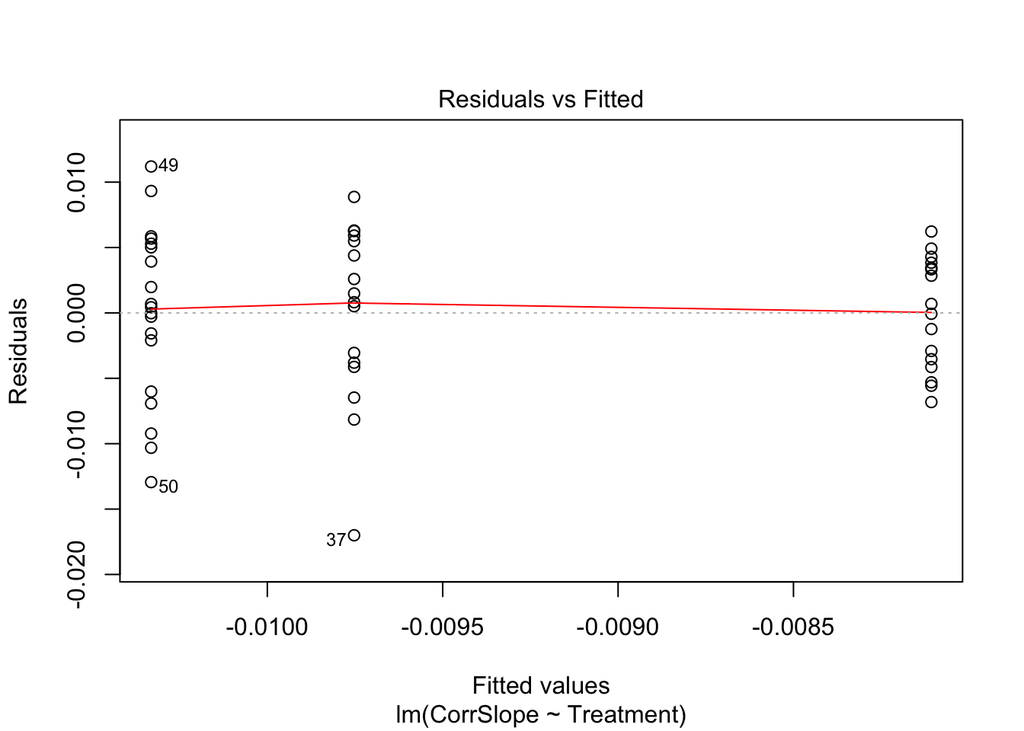

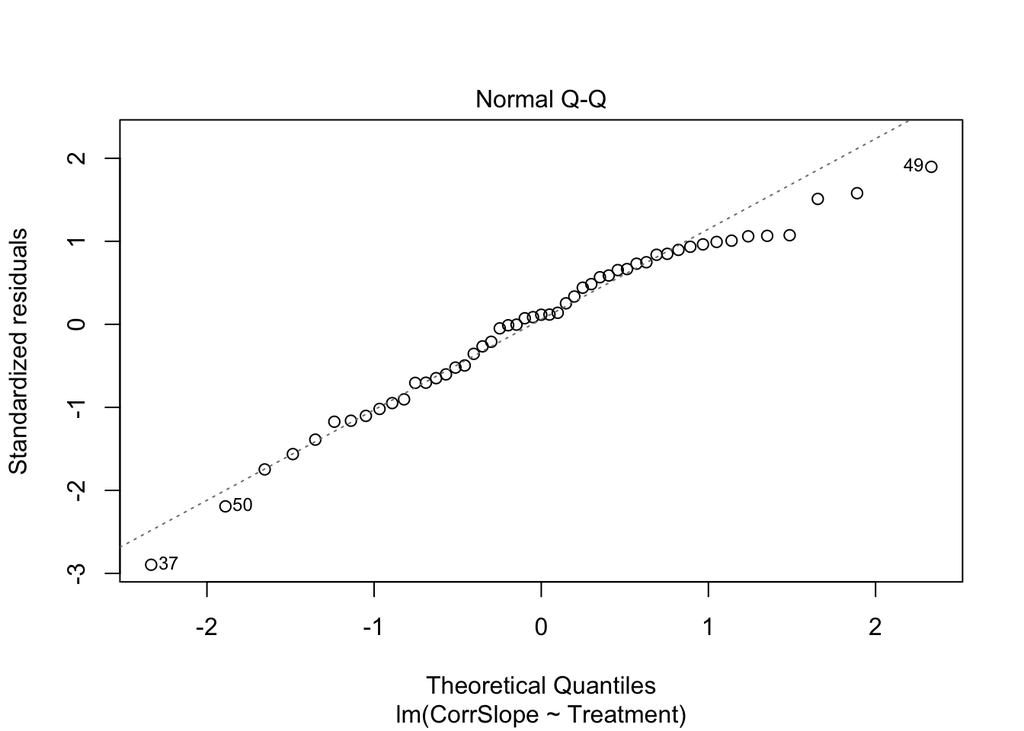

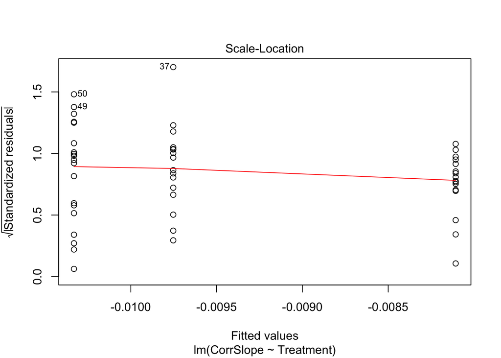

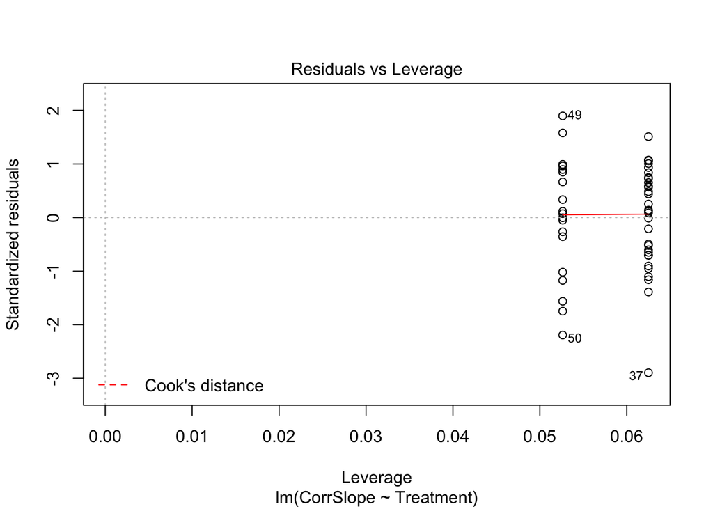

```r
plot(dSlopeFIT)
```

# 7.b) Linear Models All Change Compared Against Current and High Temperature (80%)

```r
ksSlopes.80$Treatment <- as.character(ksSlopes.80$Treatment)

ksSlope.80FIT <- lm(CorrSlope ~ Treatment, data=ksSlopes.80)
summary(ksSlope.80FIT)
```

```
##
## Call:
## lm(formula = CorrSlope ~ Treatment, data = ksSlopes.80)
##
## Residuals:
##        Min         1Q     Median         3Q        Max
## -0.0127379 -0.0020040  0.0005548  0.0020571  0.0053103
##
## Coefficients:
##                Estimate Std. Error t value Pr(>|t|)
## (Intercept)   0.0005786  0.0009022   0.641    0.524
## TreatmentCUR -0.0015858  0.0012246  -1.295    0.202
## TreatmentTMP  0.0004968  0.0012760   0.389    0.699
##
## Residual standard error: 0.003609 on 48 degrees of freedom
## Multiple R-squared:  0.06306,    Adjusted R-squared:  0.02402
## F-statistic: 1.615 on 2 and 48 DF,  p-value: 0.2094
```

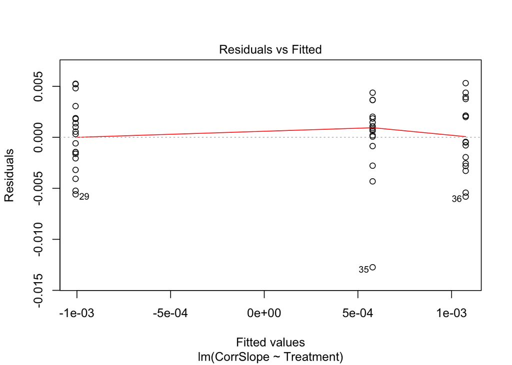

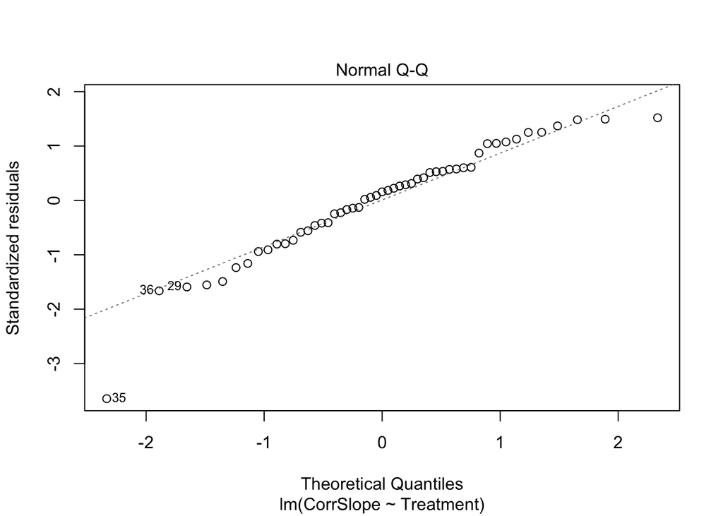

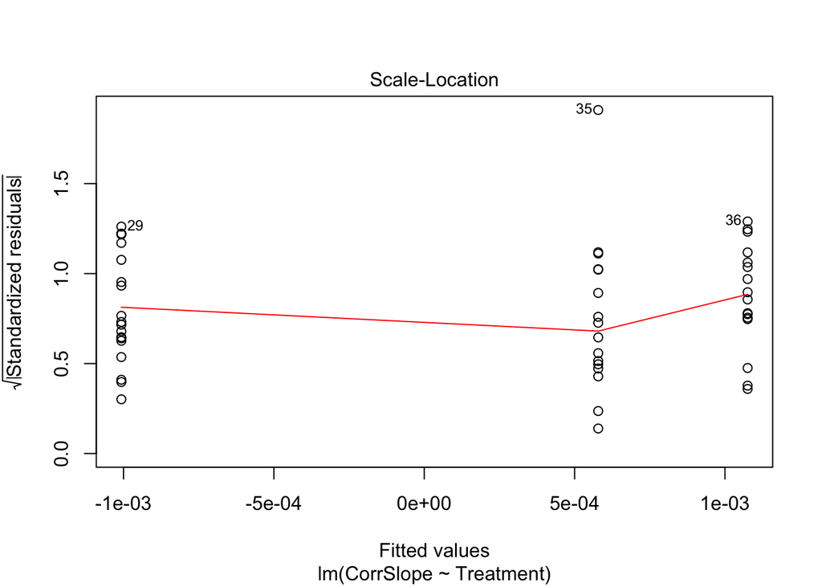

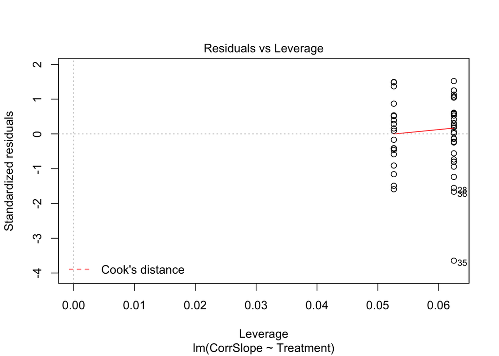

```r
plot(ksSlope.80FIT)
```

# 7.c) Linear Models All Change Compared Against Current and High Temperature (70%)

```r
ksSlopes.70$Treatment <- as.character(ksSlopes.70$Treatment)

ksSlope.70FIT <- lm(CorrSlope ~ Treatment, data=ksSlopes.70)
summary(ksSlope.70FIT)
```

```
##
## Call:
## lm(formula = CorrSlope ~ Treatment, data = ksSlopes.70)
##
## Residuals:
##       Min        1Q    Median        3Q       Max
## -0.007262 -0.001246  0.000396  0.001579  0.005268
##
## Coefficients:
##                Estimate Std. Error t value Pr(>|t|)
## (Intercept)  -0.0004976  0.0006893  -0.722    0.474
## TreatmentCUR  0.0001905  0.0009356   0.204    0.839
## TreatmentTMP  0.0007316  0.0009749   0.750    0.457
##
## Residual standard error: 0.002757 on 48 degrees of freedom
## Multiple R-squared:  0.01257,    Adjusted R-squared:  -0.02857
## F-statistic: 0.3056 on 2 and 48 DF,  p-value: 0.7381
```

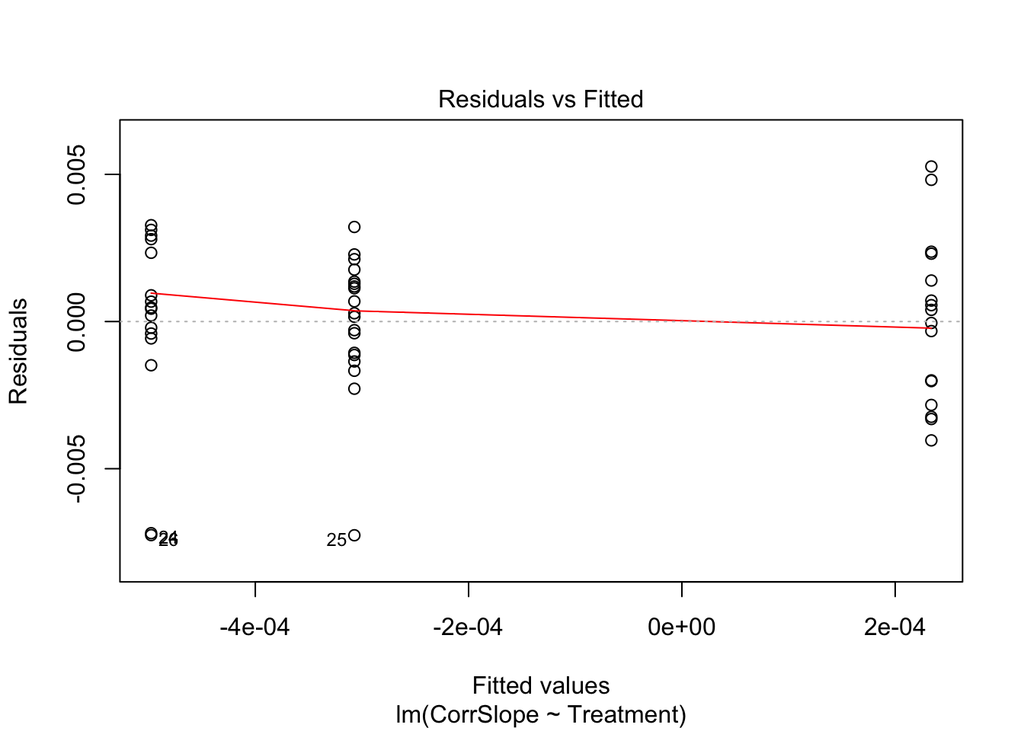

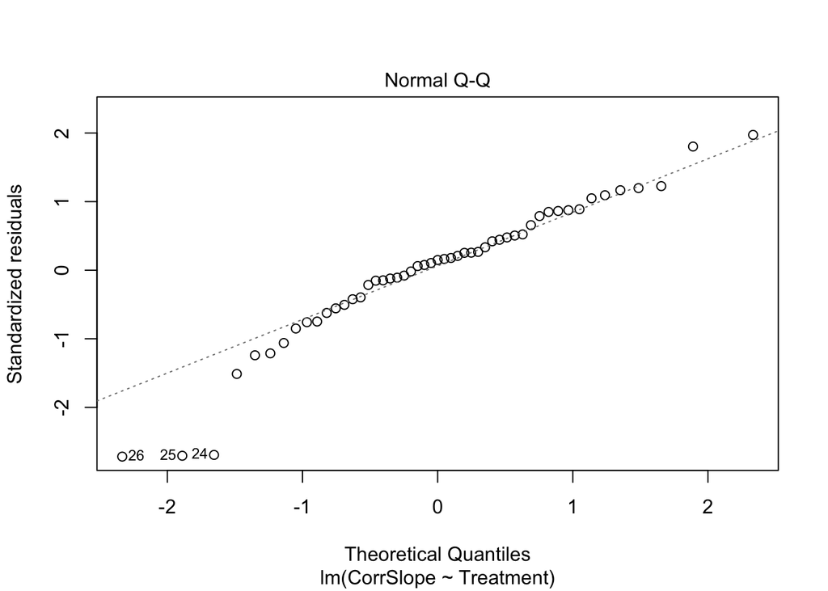

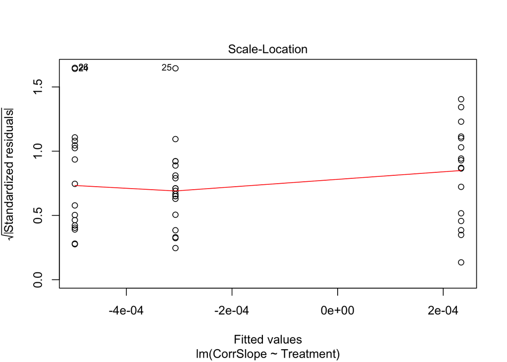

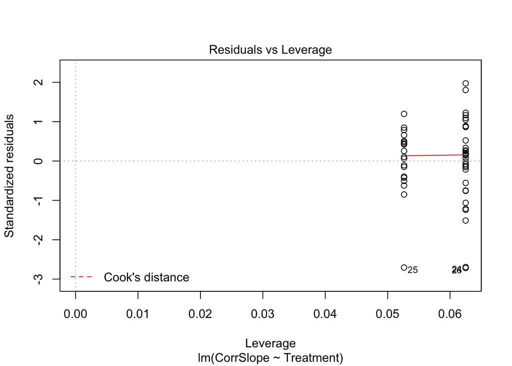

```r
plot(ksSlope.70FIT)
```

# 7.d) Linear Models All Change Compared Against Current and High Temperature (1hr)

```r
ksSlopes.1hr$Treatment <- as.character(ksSlopes.1hr$Treatment)

ksSlope.1hrFIT <- lm(CorrSlope ~ Treatment, data=ksSlopes.1hr)
summary(ksSlope.1hrFIT)
```

```
##
## Call:
## lm(formula = CorrSlope ~ Treatment, data = ksSlopes.1hr)
##
## Residuals:
##        Min         1Q     Median         3Q        Max
## -0.0155201 -0.0036256 -0.0009904  0.0027973  0.0268831
##
## Coefficients:
##                Estimate Std. Error t value Pr(>|t|)
## (Intercept)  -0.0017762  0.0020144  -0.882    0.382
## TreatmentCUR  0.0041558  0.0027341   1.520    0.135
## TreatmentTMP -0.0007243  0.0028488  -0.254    0.800
##
## Residual standard error: 0.008058 on 48 degrees of freedom
## Multiple R-squared:  0.07358,    Adjusted R-squared:  0.03498
## F-statistic: 1.906 on 2 and 48 DF,  p-value: 0.1597
```

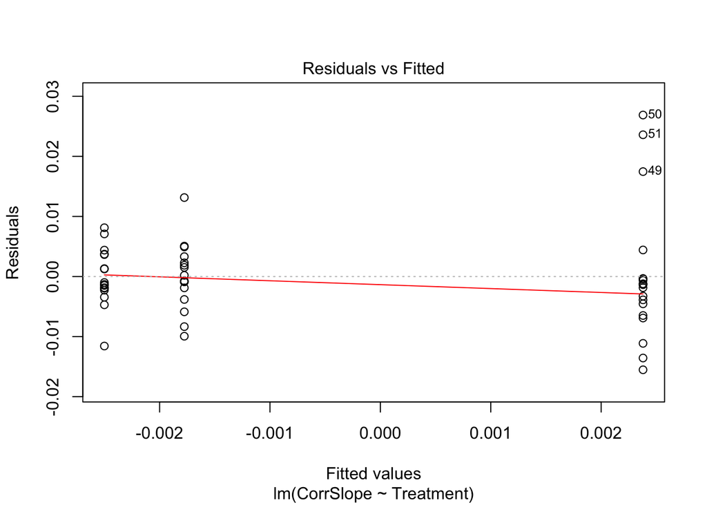

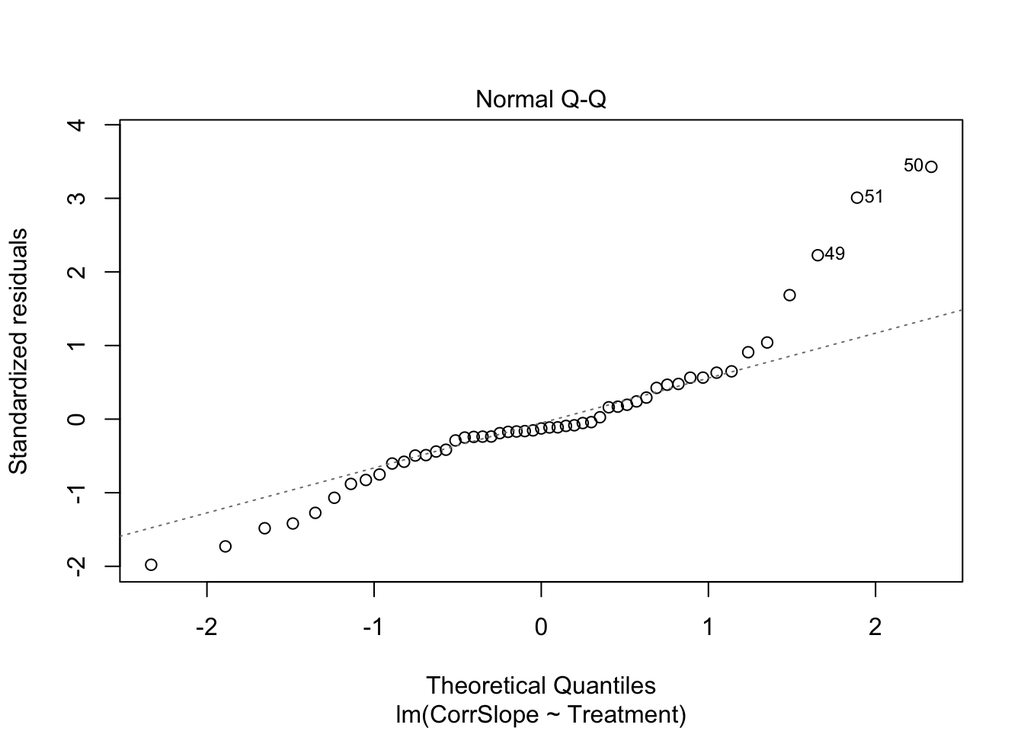

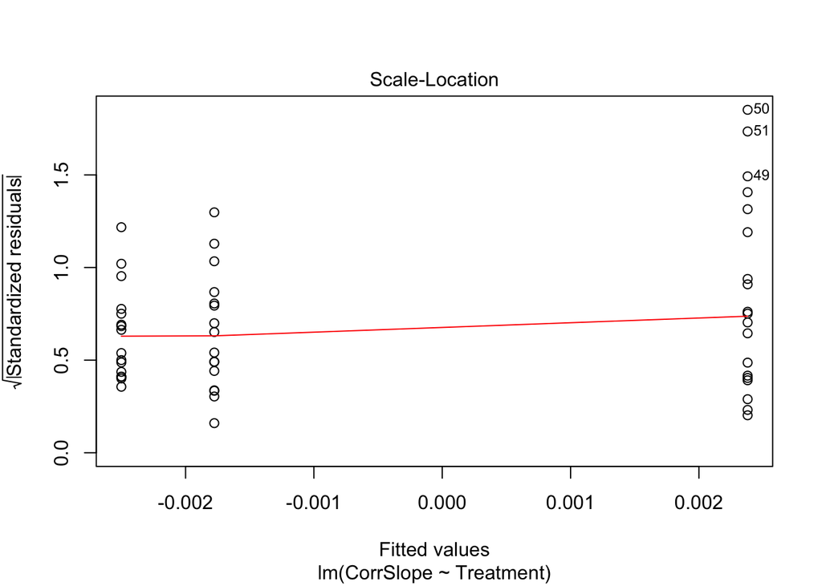

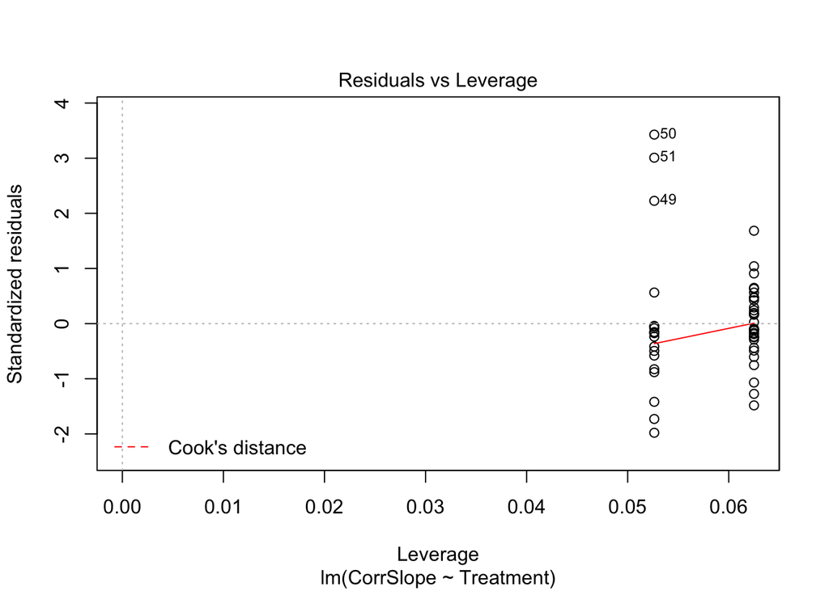

```r
plot(ksSlope.1hrFIT)
```

# Question Times 1hr Dataset

When I write the following expression does this mean that I’m looking at the relationship of (CorrSlope ~ Treatment) of each MOATs?

```r
ksSlope.1hr.MOATsFIT <- lm(CorrSlope ~ Treatment + MOATS, data=ksSlopes.1hr)
summary(ksSlope.1hr.MOATsFIT)
```

```
##
## Call:
## lm(formula = CorrSlope ~ Treatment + MOATS, data = ksSlopes.1hr)
##
## Residuals:
##       Min        1Q    Median        3Q       Max
## -0.015499 -0.003593 -0.001010  0.002819  0.026881
##
## Coefficients:
##                Estimate Std. Error t value Pr(>|t|)
## (Intercept)  -1.838e-03  3.444e-03  -0.534    0.596
## TreatmentCUR  4.141e-03  2.842e-03   1.457    0.152
## TreatmentTMP -6.904e-04  3.262e-03  -0.212    0.833
## MOATS         7.855e-06  3.555e-04   0.022    0.982
##
## Residual standard error: 0.008143 on 47 degrees of freedom
## Multiple R-squared:  0.07359,    Adjusted R-squared:  0.01446
## F-statistic: 1.245 on 3 and 47 DF,  p-value: 0.3042
```

# Want to also account for Trial ID

```r
ksSlope.1hr.MOATsTrialIDFIT <- lm(CorrSlope ~ Treatment + MOATS + TrialID, data=ksSlopes.1hr)
summary(ksSlope.1hr.MOATsTrialIDFIT)
```

```
##
## Call:
## lm(formula = CorrSlope ~ Treatment + MOATS + TrialID, data = ksSlopes.1hr)
##
## Residuals:
##        Min         1Q     Median         3Q        Max
## -0.0115129 -0.0030919 -0.0000491  0.0035575  0.0172261
##
## Coefficients:
##                  Estimate Std. Error t value Pr(>|t|)
## (Intercept)    -1.141e-05  3.756e-03  -0.003 0.997591
## TreatmentCUR   -4.801e-04  2.366e-03  -0.203 0.840144
## TreatmentTMP   -3.374e-04  2.929e-03  -0.115 0.908812
## MOATS          -2.424e-05  3.096e-04  -0.078 0.937937
## TrialIDTrial02 -3.462e-03  3.109e-03  -1.114 0.271511
## TrialIDTrial03 -4.134e-03  2.228e-03  -1.855 0.070295 .
## TrialIDTrial04  1.277e-02  3.181e-03   4.014 0.000229 ***
## ---
## Signif. codes:  0 '***' 0.001 '**' 0.01 '*' 0.05 '.' 0.1 ' ' 1
##
## Residual standard error: 0.006225 on 44 degrees of freedom
## Multiple R-squared:  0.4931, Adjusted R-squared:  0.424
## F-statistic: 7.133 on 6 and 44 DF,  p-value: 2.367e-05
```

# Rather than MOATs I’ll try Trial ID in my mixed effects model

# 9.x Trial ID

#### 9.a 1hr Dataframe - LMER

```r
lmer.ksSlopesTrialID.1hr <- lmer(CorrSlope ~ Treatment + (1|TrialID), data = ksSlopes.1hr)
summary(lmer.ksSlopesTrialID.1hr)
```

```
## Linear mixed model fit by REML. t-tests use Satterthwaite's method [
## lmerModLmerTest]
## Formula: CorrSlope ~ Treatment + (1 | TrialID)
##    Data: ksSlopes.1hr
##
## REML criterion at convergence: -335.6
##
## Scaled residuals:
##     Min      1Q  Median      3Q     Max
## -1.7352 -0.5188  0.0019  0.5690  2.9297
##
## Random effects:
##  Groups   Name        Variance  Std.Dev.
##  TrialID  (Intercept) 5.545e-05 0.007446
##  Residual             3.795e-05 0.006161
## Number of obs: 51, groups:  TrialID, 4
##
## Fixed effects:
##                Estimate Std. Error         df t value Pr(>|t|)
## (Intercept)   0.0008465  0.0040573  3.5283105   0.209    0.846
## TreatmentCUR -0.0001233  0.0022304 45.8591286  -0.055    0.956
## TreatmentTMP -0.0002550  0.0023287 45.7104836  -0.110    0.913
##
## Correlation of Fixed Effects:
##             (Intr) TrtCUR
## TreatmntCUR -0.303
## TreatmntTMP -0.243  0.433
```

```r
# All Change Against Current
# All Change Against High Temperature
```

“1hr Dataset” -still no Treatment Effect Found

#### 6.b 1hr Dataframe - LMER releved Current 1st

```r
levels(ksSlopes.1hr$Treatment)
```

```r
# lmer.ksSlopes.1hr
ksSlopes.1hr$Treatment <- fct_relevel(ksSlopes.1hr$Treatment, "CUR")
lmer.ksSlopesTrialID.1hr <- lmer(CorrSlope ~ Treatment + (1|TrialID), data = ksSlopes.1hr)
summary(lmer.ksSlopesTrialID.1hr)
```

```
## Linear mixed model fit by REML. t-tests use Satterthwaite's method [
## lmerModLmerTest]
## Formula: CorrSlope ~ Treatment + (1 | TrialID)
##    Data: ksSlopes.1hr
##
## REML criterion at convergence: -335.6
##
## Scaled residuals:
##     Min      1Q  Median      3Q     Max
## -1.7352 -0.5188  0.0019  0.5690  2.9297
##
## Random effects:
##  Groups   Name        Variance  Std.Dev.
##  TrialID  (Intercept) 5.545e-05 0.007446
##  Residual             3.795e-05 0.006161
## Number of obs: 51, groups:  TrialID, 4
##
## Fixed effects:
##                Estimate Std. Error         df t value Pr(>|t|)
## (Intercept)   0.0007232  0.0039938  3.3189806   0.181    0.867
## TreatmentCHG  0.0001233  0.0022304 45.8591287   0.055    0.956
## TreatmentTMP -0.0001317  0.0024290 46.6524305  -0.054    0.957
##
## Correlation of Fixed Effects:
##             (Intr) TrtCHG
## TreatmntCHG -0.251
## TreatmntTMP -0.235  0.503
```

```r
#**************E*N*D*************#
#*********************************
## END OF SCRIPT | END OF DOCUMENT
#*********************************
```

## END OF SCRIPT | END OF DOCUMENT